# Social Data Science - Twitter network data

David Garcia, 2021

In this tutorial we will learn how to retrieve different kinds of network data from Twitter and how to process them in R.

### Follower links

One of the most interesting networks in Twitter is the follower network, in which nodes are users and links connect user $u$ with user $v$ if $u$ follows $v$. The rtweet package allows you to get the list of followers of a user with the get_followers() function:

```r
library(rtweet)
followers <- get_followers("dgarcia_eu")
head(followers)
```

```
## # A tibble: 6 x 1
##   user_id
##   <chr>
## 1 549106573
## 2 1477158824
## 3 474552398
## 4 876408790744272896
## 5 1273197274945007616
## 6 1111628219416014849
```

The result is a data frame with a column user_id that has the ids of the followers of the user you specified. The function will require a request to the API per 5000 followers, so users with millions of followers will require many requests. This is very important because the rate limits for getting followers are very low: a standard developer account can only call make 15 requests like this per time window. As an example, it took more than 11 days to get the list of 80 million followers that Donald Trump used to have on Twitter.

Sometimes you are interested on retrieving the links in the direction they follow, which would be by getting the list of accounts followed by certain one. In the Twitter API, the people followed by a user are called the “friends” of that uses, so the get_friends() function gives you that list:

```r
followings <- get_friends("dgarcia_eu")
head(followings)
```

```
## # A tibble: 6 x 2
##   user       user_id
##   <chr>      <chr>
## 1 dgarcia_eu 753744294842929152
## 2 dgarcia_eu 1130093695993372672
## 3 dgarcia_eu 862111327023747072
## 4 dgarcia_eu 157283647
## 5 dgarcia_eu 244152149
## 6 dgarcia_eu 1710980064
```

Getting friends has also a low rate limit as in the case of followers, but at least these limits are parallel so you can request both at the same time.

The list of people we follow can tell a lot about ourselves in a similar way as [likes on Facebook reveal private attributes](https://www.pnas.org/content/110/15/5802). For example, the work of Pablo Barberá shows that following lists are useful to calculate [a score of political orientation in the US](https://journals.sagepub.com/doi/abs/10.1177/0956797615594620).

### Reply networks

First, we retrieve the basic profile information of the users of a Twitter list. Here we are using the list of professor and department accounts of ETH Zurich (https://twitter.com/i/lists/984765033673646080). The function list_members retrieves the user ids in the list and the profile objects for each user:

```r
library(dplyr)
users <- lists_members(list_id = 984765033673646080)
head(users)
```

```
## # A tibble: 6 x 40
##   user_id name  screen_name location description url   protected followers_count
##   <chr>   <chr> <chr>       <chr>    <chr>       <chr> <lgl>               <int>
## 1 135624… ETH … ETHSPH      ""       ""          <NA>  FALSE                  11
## 2 132315… Seis… SWP_ETHZur… "Zurich… "Twitter a… http… FALSE                 213
## 3 130949… Juli… DannathJul… "Zurich… "This is t… http… FALSE                 167
## 4 128555… Quan… ETHQuantum… "Zurich… "The offic… http… FALSE                 199
## 5 127577… ETH … ETH_Mesosys "ETH Zu… "Joint lab… http… FALSE                  43
## 6 127026… Cent… pblcenter_… "Zurich" "PBL Cente… http… FALSE                  31
## # … with 32 more variables: friends_count <int>, listed_count <int>,
## #   created_at <dttm>, favourites_count <int>, utc_offset <lgl>,
## #   time_zone <lgl>, geo_enabled <lgl>, verified <lgl>, statuses_count <int>,
## #   lang <lgl>, contributors_enabled <lgl>, is_translator <lgl>,
## #   is_translation_enabled <lgl>, profile_background_color <chr>,
## #   profile_background_image_url <chr>,
## #   profile_background_image_url_https <chr>, profile_background_tile <lgl>,
## #   profile_image_url <chr>, profile_image_url_https <chr>,
## #   profile_link_color <chr>, profile_sidebar_border_color <chr>,
## #   profile_sidebar_fill_color <chr>, profile_text_color <chr>,
## #   profile_use_background_image <lgl>, has_extended_profile <lgl>,
## #   default_profile <lgl>, default_profile_image <lgl>, following <lgl>,
## #   follow_request_sent <lgl>, notifications <lgl>, translator_type <chr>,
## #   profile_banner_url <chr>
```

```r
nrow(users)
```

```
## [1] 246
```

We are going to focus on a random sample of 100 and retrieve their latest 100 tweets with the get_timelines() function:

```r
userids <- sample(users$user_id, 100)
tweets <- get_timelines(userids, n=100)
head(tweets)
```

```
## # A tibble: 6 x 90
##   user_id status_id created_at          screen_name text  source
##   <chr>   <chr>     <dttm>              <chr>       <chr> <chr>
## 1 489555… 13112677… 2020-09-30 11:32:38 NEZimmerma… "Gre… Twitt…
## 2 489555… 13064968… 2020-09-17 07:34:48 NEZimmerma… "Nic… Twitt…
## 3 489555… 12368906… 2020-03-09 05:44:37 NEZimmerma… "#Ph… Twitt…
## 4 489555… 12368906… 2020-03-09 05:44:34 NEZimmerma… "#Ph… Twitt…
## 5 489555… 11971016… 2019-11-20 10:37:19 NEZimmerma… "Ver… Twitt…
## 6 489555… 11772254… 2019-09-26 14:16:30 NEZimmerma… "Sup… Twitt…
## # … with 84 more variables: display_text_width <dbl>, reply_to_status_id <chr>,
## #   reply_to_user_id <chr>, reply_to_screen_name <chr>, is_quote <lgl>,
## #   is_retweet <lgl>, favorite_count <int>, retweet_count <int>,
## #   quote_count <int>, reply_count <int>, hashtags <list>, symbols <list>,
## #   urls_url <list>, urls_t.co <list>, urls_expanded_url <list>,
## #   media_url <list>, media_t.co <list>, media_expanded_url <list>,
## #   media_type <list>, ext_media_url <list>, ext_media_t.co <list>,
## #   ext_media_expanded_url <list>, ext_media_type <chr>,
## #   mentions_user_id <list>, mentions_screen_name <list>, lang <chr>,
## #   quoted_status_id <chr>, quoted_text <chr>, quoted_created_at <dttm>,
## #   quoted_source <chr>, quoted_favorite_count <int>,
## #   quoted_retweet_count <int>, quoted_user_id <chr>, quoted_screen_name <chr>,
## #   quoted_name <chr>, quoted_followers_count <int>,
## #   quoted_friends_count <int>, quoted_statuses_count <int>,
## #   quoted_location <chr>, quoted_description <chr>, quoted_verified <lgl>,
## #   retweet_status_id <chr>, retweet_text <chr>, retweet_created_at <dttm>,
## #   retweet_source <chr>, retweet_favorite_count <int>,
## #   retweet_retweet_count <int>, retweet_user_id <chr>,
## #   retweet_screen_name <chr>, retweet_name <chr>,
## #   retweet_followers_count <int>, retweet_friends_count <int>,
## #   retweet_statuses_count <int>, retweet_location <chr>,
## #   retweet_description <chr>, retweet_verified <lgl>, place_url <chr>,
## #   place_name <chr>, place_full_name <chr>, place_type <chr>, country <chr>,
## #   country_code <chr>, geo_coords <list>, coords_coords <list>,
## #   bbox_coords <list>, status_url <chr>, name <chr>, location <chr>,
## #   description <chr>, url <chr>, protected <lgl>, followers_count <int>,
## #   friends_count <int>, listed_count <int>, statuses_count <int>,
## #   favourites_count <int>, account_created_at <dttm>, verified <lgl>,
## #   profile_url <chr>, profile_expanded_url <chr>, account_lang <lgl>,
## #   profile_banner_url <chr>, profile_background_url <chr>,
## #   profile_image_url <chr>
```

Accessing timelines in Twitter has a much higher limit of 900 requests per 15-minute window. This way you can get at most 3200 tweets per user and you have another limit of at most [100000 calls per 24-hour period.](https://developer.twitter.com/en/docs/twitter-api/v1/tweets/timelines/api-reference/get-statuses-user_timeline)

Tweets that are replies will generate rows in the result with the reply_to_user_id column set to the numeric id of the user being replied to:

```r
head(tweets$reply_to_user_id, n=20)
```

```
##  [1] NA NA NA NA NA NA NA NA NA NA NA NA NA NA NA NA NA NA NA NA
```

We can extract all reply links in our data by taking this information and filtering for users in our sample:

```r
tweets %>%
  select(user_id, reply_to_user_id) %>%
  filter(!is.na(reply_to_user_id)) %>%
  inner_join(data.frame(user_id=userids)) %>%
  inner_join(data.frame(reply_to_user_id=userids)) -> repliesdf
dim(repliesdf)
```

```
## [1] 547   2
```

And construct the edges by counting reply instances as their weight:

```r
names(repliesdf) <- c("from", "to")
repliesdf %>%
  group_by(to, from) %>%
  summarize(weight = n()) -> edgesdf
head(edgesdf)
```

```
## # A tibble: 6 x 3
## # Groups:   to [5]
##   to                  from                weight
##   <chr>               <chr>                <int>
## 1 1025692751847989248 1025692751847989248     22
## 2 1031222219131834369 1031222219131834369     24
## 3 1039125456086282240 1039125456086282240      3
## 4 1047807847738888192 1047807847738888192      3
## 5 1064812518206554113 1064812518206554113      1
## 6 1064812518206554113 346179882                1
```

We can then create the graph and plot it:

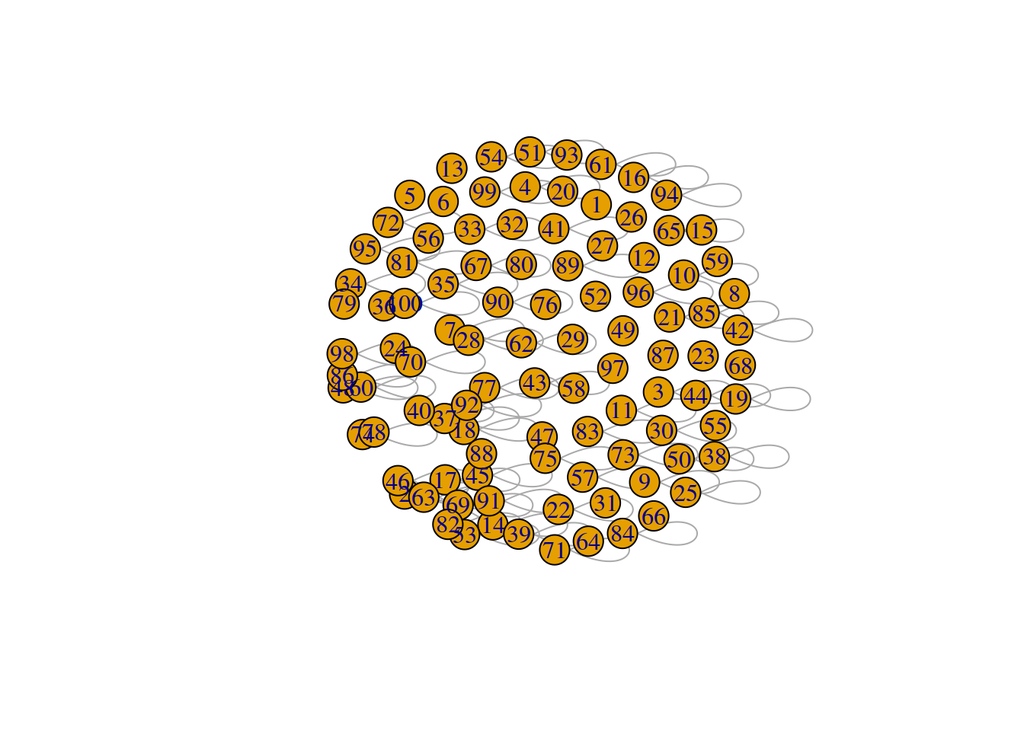

```r
library(tidygraph)
graph<-tbl_graph(data.frame(id=userids),edgesdf, directed=F, node_key = "id")
plot(graph)
```

If you see many self-loops, that might be due to accounts building threads of replies.

### Retweet networks

You can follow a similar process to build a retweet network. First, we extract entries using the retweet_user_id column:

```r
tweets %>%
  select(user_id, retweet_user_id) %>%
  filter(!is.na(retweet_user_id)) %>%
  inner_join(data.frame(user_id=userids)) %>%
  inner_join(data.frame(retweet_user_id=userids)) -> retweetsdf
dim(retweetsdf)
```

```
## [1] 230   2
```

We then construct edges. The directionality of retween networks can be decided in both ways, either from retweeted to retweeted as an information flow network or from retweeter to retweeted as a “giving credit” or endorsement network. We choose this last option to resemple the follower networks:

```r
names(retweetsdf) <- c("from", "to")
retweetsdf %>%
  group_by(to, from) %>%
  summarize(weight = n()) -> edgesdf
head(edgesdf)
```

```
## # A tibble: 6 x 3
## # Groups:   to [6]
##   to                  from                weight
##   <chr>               <chr>                <int>
## 1 1031222219131834369 295507571                1
## 2 1047808609210589184 934090570930286593       1
## 3 1064812518206554113 346179882               15
## 4 1073187048935342080 1073187048935342080      2
## 5 1074588131222020097 1074588131222020097      3
## 6 1088464875519655937 818560246654201860       1
```

And then we can plot as we did with the replies network:

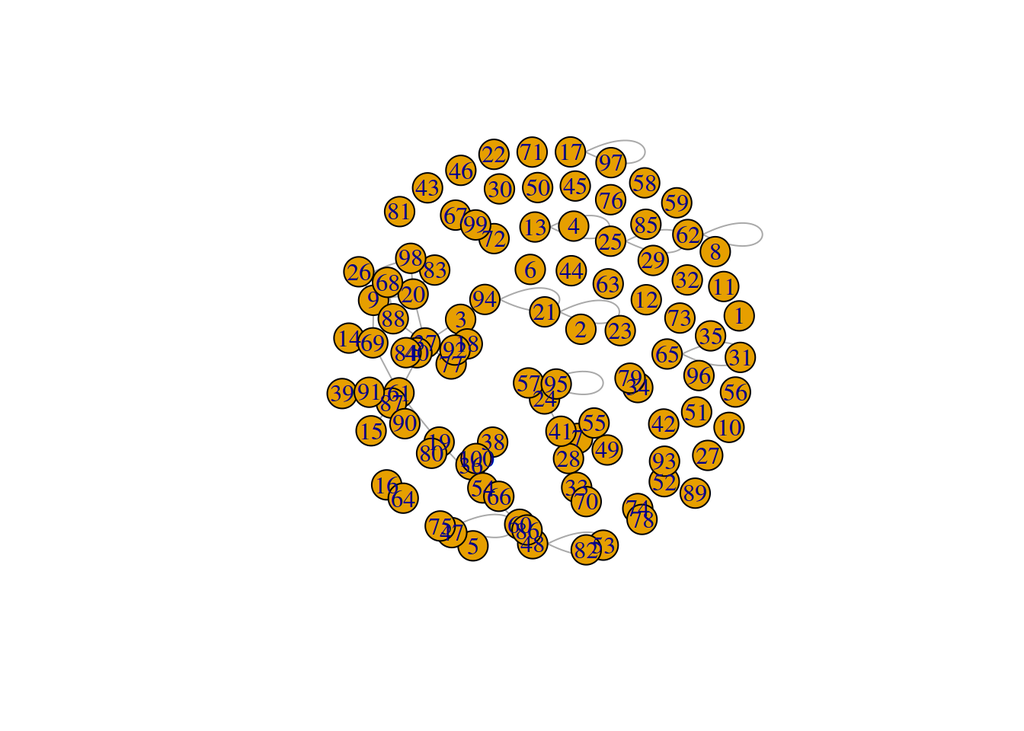

```r
graph<-tbl_graph(data.frame(id=userids),edgesdf, directed=F, node_key = "id")
plot(graph)
```

You might notice quite some differences here, for example there are less self-loops. Users are less likely to retweet themselves than reply to themselves on Twitter.

### Likes information

Twitter allows you to get some data on the likes given by a user to tweets with the get_favorites() function:

```r
likes <- get_favorites("dgarcia_eu", n = 2000)
head(likes)
```

```
## # A tibble: 6 x 91
##   user_id status_id created_at          screen_name text  source
##   <chr>   <chr>     <dttm>              <chr>       <chr> <chr>
## 1 222881… 13625259… 2021-02-18 22:14:44 lewis_math  "Tha… Twitt…
## 2 222881… 12915237… 2020-08-06 23:57:06 lewis_math  "Thr… Twitt…
## 3 222881… 12082513… 2019-12-21 05:02:18 lewis_math  "Thi… Twitt…
## 4 222881… 13193135… 2020-10-22 16:24:02 lewis_math  "@dg… Twitt…
## 5 222881… 12908671… 2020-08-05 04:27:56 lewis_math  "I w… Tweet…
## 6 801042… 13624237… 2021-02-18 15:28:35 dnds_ceu    "New… Twitt…
## # … with 85 more variables: display_text_width <dbl>, reply_to_status_id <chr>,
## #   reply_to_user_id <chr>, reply_to_screen_name <chr>, is_quote <lgl>,
## #   is_retweet <lgl>, favorite_count <int>, retweet_count <int>,
## #   quote_count <int>, reply_count <int>, hashtags <list>, symbols <list>,
## #   urls_url <list>, urls_t.co <list>, urls_expanded_url <list>,
## #   media_url <list>, media_t.co <list>, media_expanded_url <list>,
## #   media_type <list>, ext_media_url <list>, ext_media_t.co <list>,
## #   ext_media_expanded_url <list>, ext_media_type <chr>,
## #   mentions_user_id <list>, mentions_screen_name <list>, lang <chr>,
## #   quoted_status_id <chr>, quoted_text <chr>, quoted_created_at <dttm>,
## #   quoted_source <chr>, quoted_favorite_count <int>,
## #   quoted_retweet_count <int>, quoted_user_id <chr>, quoted_screen_name <chr>,
## #   quoted_name <chr>, quoted_followers_count <int>,
## #   quoted_friends_count <int>, quoted_statuses_count <int>,
## #   quoted_location <chr>, quoted_description <chr>, quoted_verified <lgl>,
## #   retweet_status_id <chr>, retweet_text <chr>, retweet_created_at <dttm>,
## #   retweet_source <chr>, retweet_favorite_count <int>,
## #   retweet_retweet_count <int>, retweet_user_id <chr>,
## #   retweet_screen_name <chr>, retweet_name <chr>,
## #   retweet_followers_count <int>, retweet_friends_count <int>,
## #   retweet_statuses_count <int>, retweet_location <chr>,
## #   retweet_description <chr>, retweet_verified <lgl>, place_url <chr>,
## #   place_name <chr>, place_full_name <chr>, place_type <chr>, country <chr>,
## #   country_code <chr>, geo_coords <list>, coords_coords <list>,
## #   bbox_coords <list>, status_url <chr>, name <chr>, location <chr>,
## #   description <chr>, url <chr>, protected <lgl>, followers_count <int>,
## #   friends_count <int>, listed_count <int>, statuses_count <int>,
## #   favourites_count <int>, account_created_at <dttm>, verified <lgl>,
## #   profile_url <chr>, profile_expanded_url <chr>, account_lang <lgl>,
## #   profile_banner_url <chr>, profile_background_url <chr>,
## #   profile_image_url <chr>, favorited_by <chr>
```

The result is a dataframe with the latest tweets liked by the user. A request this way gives you the latest 200 likes, thus the above code can take up to 10 requests. The rate limit for this is 75 requests per 15-min window, so building the likes network for the above list of Twitter users would take a while. The naming of “favorites” instead of likes comes from the earlier desgin of Twitter, where likes did not exist and users could favorite tweets with a star symbol. Now it’s a heart and since the change to likes, it is used much more frequently.

### To learn more

- Get the whole follower list overnight for a set of accounts and plot the resulting network
- With the resulting data, you can measure the overlap in followers between two users as the [Jaccard coefficient](https://en.wikipedia.org/wiki/Jaccard_index). This gives you an undirected, weighted network of follower similarity that you can also plot.
- Build reply and retweet network for the example above but getting all tweets up to the 3200-tweet limit. Is it different from the one plotted based on a sample?
- Based on the latest tweets of a user, you can calculate the T-index of the user as the maximum number T such that the user has posted T tweets with at least T likes (similar to the h-index for scientists). Which account from ETH has the highest T-index?